# M2.951_20192_Pràctica2

Oriol Calvo i Josep Adrian

Maig-Juny 2020

Llibreries que s’utiliten al llarg del notebook:

```r
library(lubridate)
library(ggplot2)
library(dplyr)
library(gridExtra)
library(VIM)
library(ggpubr)
library(con2aqi)
library(zoo)
library(nortest)
library(forecast)
library(corrplot)
```

# 1. Descripció del dataset.

## 1.1 Perquè és important i quina pregunta/problema pretén respondre?

Escollim el dataset [“Beijing Multiset Air Quality”](https://archive.ics.uci.edu/ml/datasets/Beijing+Multi-Site+Air-Quality+Data) de UC Irvine Machine Learning

El dataset inclou medicions de diferents indicadors de contaminació ambiental recollides en 12 estacions atmosfèriques de la ciutat de Pequín, recollides entre el 1r de març de 2013 i el 28 de febrer de 2017.

L’estudi del dataset pretén arribar a conclusions rellevants sobre la qualitat de l’aire en aquesta ciutat asiàtica, una de les més contaminades del món segons diversos ranquings, que permetin a les autoritats prendre mesures per a reduïr la contaminació, i millorar així la qualitat de vida dels seus habitants, aconseguint també revertir l’efecte del canvi climàtic.

## 1.2 Descripció del dataset

El dataset es composa de 12 fitxers, cadascun d’aquets correspon a una estació de control de qualitat de l’aire d’on s’han obtingut mesures a cada hora des de 2013 fins al 2017. Cada fitxer per separat contè 35064 observacions.

- **No**: Número d’observació.
- **year**: Any de les dades.
- **month**: Mes de les dades.
- **day**: Dia de les dades.
- **hour**: Hora de les dades.
- **PM2.5**: Concentració del contaminant PM2,5 ($\mu g/m^3$).
- **PM10**: Concentració del contaminant PM10 ($\mu g/m^3$).
- **SO2**: Concentració de diòxid de sofre ($\mu g/m^3$).
- **NO2**: Concentració de diòxid de nitrogen ($\mu g/m^3$).
- **CO**: Concentració de monòxid de carboni ($\mu g/m^3$).
- **O3**: Concentració d’ozó ($\mu g/m^3$).
- **TEMP**: Temperatura (graus Celsius).
- **PRES**: Pressió ($hPa$).
- **DEWP**: Punt de rosada, temperatura a la qual ha de baixar una massa d’aire, a pressió constant, perquè la humitat relativa arribi al 100% (graus Celsius).
- **RAIN**: Preciptació ($mm$).
- **wd**: Direcció del vent.
- **WSPM**: Velocitat del vent ($m/s$).
- **station**: nom de l’estació de control.

# 2. Integració i selecció de les dades d’interès a analitzar.

## 2.1 Càrrega fitxer

Carreguem el fitxer i en mostrem estadístics bàsics

```r
rm(list=ls())

ruta="PRSA_Data_20130301-20170228/"

fitxers=list.files(ruta)

dades<-read.csv(paste(ruta,fitxers[1],sep=""), header=T, sep=",")

for (i in 2:length(fitxers)) {
  dades_i<-read.csv(paste(ruta,fitxers[i],sep=""), header=T, sep=",")
  dades=rbind(dades,dades_i)
}
write.csv(dades,"Dades_modificades.csv")
rm(dades_i,i,fitxers,ruta)
```

## 2.2 Preparació de les dades

A continuació discretitzarem algunes de les dades del conjunt, que es presenten originalment de forma contínua. La discretització ens ajudara a treballar millor amb les dades i a explicar-les millor de manera que els resultats siguin més rellevants i entenedors.

Primerament observem el dataset per veure quins valors poden ser discretitzats.

```r
apply(dades,2, function(x) length(unique(x)))
```

```
##      No    year   month     day    hour   PM2.5    PM10     SO2     NO2
##   35064       5      12      31      24     889    1085     692    1213
##      CO      O3    TEMP    PRES    DEWP    RAIN      wd    WSPM station
##     133    1599    2016     723     646     254      17     118      12
```

Discretitzem les variables amb menys classes, que funcionalment representen variables categòriques (dies, hores, direcció del vent…).

```r
# any
dades$year=as.factor(dades$year)
# mes
dades$month=as.factor(dades$month)
# dia
dades$day=as.factor(dades$day)
# hora
dades$hour=as.factor(dades$hour)
# direcció del vent
dades$wd=as.factor(dades$wd)
# nom de l'estació
dades$station=as.factor(dades$station)
```

### 2.2.1 Creació de nous atributs

Creem noves variables

- **RAIN_BOOL**: indica si plovia en aquella medició.
- **WIND**: indica si feia vent en aquella medició.
- **Direccio**: indica la direcció del vent en graus.
- **Data_Cal**: data de la observació creada a partir de dia-mes-any.
- **Estacio_any**: Hivern, Primavera, Estiu o Tardor (segons el mes).

```r
# RAIN_BOOL
dades$RAIN_BOOL<-"Pluja"
dades$RAIN_BOOL[dades$RAIN==0]<-"Sense pluja"
dades$RAIN_BOOL<-as.factor(dades$RAIN_BOOL)

# WIND
dades$WIND<-"Vent"
dades$WIND[dades$WSPM<1]<-"Sense vent"
dades$WIND<-as.factor(dades$WIND)

# direccio
dades$direccio[dades$wd=="N"]<-0
dades$direccio[dades$wd=="NNE"]<-22.5
dades$direccio[dades$wd=="NE"]<-45
dades$direccio[dades$wd=="ENE"]<-67.5
dades$direccio[dades$wd=="E"]<-90
dades$direccio[dades$wd=="ESE"]<-112.5
dades$direccio[dades$wd=="SE"]<-135
dades$direccio[dades$wd=="SSE"]<-157.5
dades$direccio[dades$wd=="S"]<-180
dades$direccio[dades$wd=="SSW"]<-202.5
dades$direccio[dades$wd=="SW"]<-225
dades$direccio[dades$wd=="WSW"]<-247.5
dades$direccio[dades$wd=="W"]<-270
dades$direccio[dades$wd=="WNW"]<-292.5
dades$direccio[dades$wd=="NW"]<-315
dades$direccio[dades$wd=="NNW"]<-337.5
#dades$direccio=as.factor(dades$direccio)

# Data_Cal
dades$Data_Cal <- ymd_h(paste(dades$year, dades$month, dades$day, dades$hour, sep= ' '))

# estacio_any
dades$estacio_any[dades$month==1 |dades$month==2|dades$month==3]<-"Hivern"
dades$estacio_any[dades$month==4 |dades$month==5|dades$month==6]<-"Primavera"
dades$estacio_any[dades$month==7 |dades$month==8|dades$month==9]<-"Estiu"
dades$estacio_any[dades$month==10 |dades$month==11|dades$month==12]<-"Tardor"
dades$estacio_any=as.factor(dades$estacio_any)
```

A continuació generem el mateix dataset amb una reducció d’intàncies. L’objectiu és calcular l’índex AQI per estudiar la qualita del aire. Aquest index es calcula de moltes maneres. La manera que hem escollit és amb el promig temporal de 24h dels indicadors *PM2.5*i*PM10*.

Per fer aixo caldrà fer aquesta reducció:

```r
red.dim <- function(df,dx){

  att.avg <- c("PM2.5","PM10","SO2","NO2","CO","O3","TEMP","PRES","RAIN","WSPM","direccio")
  att.sampling <-c("station","Data_Cal")

  aux <- aggregate(df[att.avg],list(rep(1:(nrow(df[att.avg])%/%dx+1),each=dx,len=nrow(df[att.avg]))),mean)[-1]
  vector.aux1 <- seq(1,nrow(df),by = dx)
  aux1 <- df[att.sampling]
  aux1 <- aux1[vector.aux1,]
  aux2 <- bind_cols(aux,aux1)

  return(aux2)
}

dades.24h <- red.dim(dades,24)
dades.24h$direccio <- as.factor(dades.24h$direccio)
dades$direccio <- as.factor(dades$direccio)
head(dades.24h)
```

|  | PM2.5 | PM10 | SO2 | NO2 | CO | O3 | TEMP | PRES | RAIN | WSPM | direccio | station | Data_Cal |
| --- | --- | --- | --- | --- | --- | --- | --- | --- | --- | --- | --- | --- | --- |
| 1 | 7.12500 | 10.75000 | 11.70833 | 22.58333 | 429.1667 | 63.87500 | 1.3916667 | 1026.875 | 0 | 3.254167 | 150 | Aotizhongxin | 2013-03-01 |
| 2 | 30.75000 | 42.08333 | 36.62500 | 66.66667 | 824.9167 | 29.75000 | 0.6166667 | 1026.850 | 0 | 1.479167 | 135 | Aotizhongxin | 2013-03-02 |
| 3 | 76.91667 | 120.54167 | 61.29167 | 81.00000 | 1620.6250 | 19.12500 | 5.5666667 | 1014.608 | 0 | 1.658333 | 129.375 | Aotizhongxin | 2013-03-03 |
| 4 | 22.70833 | 44.58333 | NA | NA | NA | 53.75000 | 9.9625000 | 1017.650 | 0 | 2.404167 | 121.875 | Aotizhongxin | 2013-03-04 |
| 5 | 148.87500 | 183.79167 | 93.87500 | 132.83333 | 2357.9583 | 68.45833 | 6.2916667 | 1010.900 | 0 | 1.129167 | 68.4375 | Aotizhongxin | 2013-03-05 |
| 6 | 223.25000 | 265.16667 | 116.23670 | 142.05938 | NA | 19.75000 | 7.1833333 | 1007.483 | 0 | 1.483333 | 117.1875 | Aotizhongxin | 2013-03-06 |

## 2.4 Anàlisi descriptiva

A continuació classifiquem els atributs en funció del tipus de variable:

- **No**: Variable quantitativa discreta.
- **year**: Variable quantitativa discreta.
- **month**: Variable quantitativa discreta.
- **day**: Variable quantitativa discreta.
- **hour**: Variable quantitativa discreta.
- **PM2.5**: Variable quantitativa continua.
- **PM10**: Variable quantitativa continua.
- **SO2**: Variable quantitativa continua.
- **NO2**: Variable quantitativa continua.
- **CO**: Variable quantitativa continua.
- **O3**: Variable quantitativa continua.
- **TEMP**: Variable quantitativa continua.
- **PRES**: Variable quantitativa continua.
- **DEWP**: Variable quantitativa continua.
- **wd**: Variable qualitativa Nominal.
- **WSPM**: Variable quantitativa continua.
- **station**: Variable qualitativa nominal.
- **RAIN_BOOL**: Variable qualitativa dicotòmica.
- **WIND**: Variable qualitativa dicotòmica.
- **Direccio**: Variable quantitativa continua.
- **Data_Cal**: Variable quantitativa discreta.
- **Estacio_any**: Variable qualitativa nominal.

### 2.4.1 Estadística descriptiva

Mostrem les mesures de tendència central i les mesures de dipersió pels atributs del conjunt de dades. Per al contjunt d’atributs quantitatius mostrarem els valors mínims, màxims, mediana, mitjana i quantils. En el cas dels atributs qualitatius mostrarem les seves freqüències.

Primer es mostra la descripció del dataset original:

```r
summary(dades)
```

```
##        No          year            month             day
##  Min.   :    1   2013: 88128   1      : 35712   1      : 13824
##  1st Qu.: 8767   2014:105120   3      : 35712   2      : 13824
##  Median :17533   2015:105120   5      : 35712   3      : 13824
##  Mean   :17533   2016:105408   7      : 35712   4      : 13824
##  3rd Qu.:26298   2017: 16992   8      : 35712   5      : 13824
##  Max.   :35064                 10     : 35712   6      : 13824
##                                (Other):206496   (Other):337824
##       hour            PM2.5             PM10            SO2
##  0      : 17532   Min.   :  2.00   Min.   :  2.0   Min.   :  0.286
##  1      : 17532   1st Qu.: 20.00   1st Qu.: 36.0   1st Qu.:  3.000
##  2      : 17532   Median : 55.00   Median : 82.0   Median :  7.000
##  3      : 17532   Mean   : 79.79   Mean   :104.6   Mean   : 15.831
##  4      : 17532   3rd Qu.:111.00   3rd Qu.:145.0   3rd Qu.: 20.000
##  5      : 17532   Max.   :999.00   Max.   :999.0   Max.   :500.000
##  (Other):315576   NA's   :8739     NA's   :6449    NA's   :9021
##       NO2                CO              O3                TEMP
##  Min.   :  1.026   Min.   :  100   Min.   :   0.214   Min.   :-19.90
##  1st Qu.: 23.000   1st Qu.:  500   1st Qu.:  11.000   1st Qu.:  3.10
##  Median : 43.000   Median :  900   Median :  45.000   Median : 14.50
##  Mean   : 50.639   Mean   : 1231   Mean   :  57.372   Mean   : 13.54
##  3rd Qu.: 71.000   3rd Qu.: 1500   3rd Qu.:  82.000   3rd Qu.: 23.30
##  Max.   :290.000   Max.   :10000   Max.   :1071.000   Max.   : 41.60
##  NA's   :12116     NA's   :20701   NA's   :13277      NA's   :398
##       PRES             DEWP              RAIN               wd
##  Min.   : 982.4   Min.   :-43.400   Min.   : 0.0000   NE     : 43335
##  1st Qu.:1002.3   1st Qu.: -8.900   1st Qu.: 0.0000   ENE    : 34142
##  Median :1010.4   Median :  3.100   Median : 0.0000   NW     : 32600
##  Mean   :1010.7   Mean   :  2.491   Mean   : 0.0645   N      : 30869
##  3rd Qu.:1019.0   3rd Qu.: 15.100   3rd Qu.: 0.0000   E      : 29752
##  Max.   :1042.8   Max.   : 29.100   Max.   :72.5000   (Other):248248
##  NA's   :393      NA's   :403       NA's   :390       NA's   :  1822
##       WSPM               station             RAIN_BOOL
##  Min.   : 0.00   Aotizhongxin: 35064   Pluja      : 16910
##  1st Qu.: 0.90   Changping   : 35064   Sense pluja:403858
##  Median : 1.40   Dingling    : 35064
##  Mean   : 1.73   Dongsi      : 35064
##  3rd Qu.: 2.20   Guanyuan    : 35064
##  Max.   :13.20   Gucheng     : 35064
##  NA's   :318     (Other)     :210384
##          WIND           direccio         Data_Cal
##  Sense vent:113174   45     : 43335   Min.   :2013-03-01 00:00:00
##  Vent      :307594   67.5   : 34142   1st Qu.:2014-03-01 05:45:00
##                      315    : 32600   Median :2015-03-01 11:30:00
##                      0      : 30869   Mean   :2015-03-01 11:30:00
##                      90     : 29752   3rd Qu.:2016-02-29 17:15:00
##                      (Other):248248   Max.   :2017-02-28 23:00:00
##                      NA's   :  1822
##     estacio_any
##  Estiu    :105984
##  Hivern   :103968
##  Primavera:104832
##  Tardor   :105984
##
##
##
```

Després es mostra el dataset amb la reducció d’instàncies:

```r
summary(dades.24h)
```

```
##      PM2.5             PM10              SO2               NO2
##  Min.   :  3.00   Min.   :  4.833   Min.   :  1.000   Min.   :  2.00
##  1st Qu.: 30.57   1st Qu.: 49.458   1st Qu.:  3.833   1st Qu.: 31.38
##  Median : 60.71   Median : 87.917   Median :  9.042   Median : 46.04
##  Mean   : 79.82   Mean   :104.293   Mean   : 15.515   Mean   : 51.05
##  3rd Qu.:107.59   3rd Qu.:137.042   3rd Qu.: 20.167   3rd Qu.: 65.38
##  Max.   :567.42   Max.   :584.667   Max.   :156.417   Max.   :193.33
##  NA's   :2388     NA's   :1959      NA's   :2472      NA's   :3240
##        CO               O3              TEMP              PRES
##  Min.   : 100.0   Min.   :  1.00   Min.   :-15.683   Min.   : 985.8
##  1st Qu.: 612.5   1st Qu.: 26.61   1st Qu.:  3.221   1st Qu.:1002.2
##  Median : 941.7   Median : 52.58   Median : 15.129   Median :1010.4
##  Mean   :1216.5   Mean   : 57.82   Mean   : 13.628   Mean   :1010.7
##  3rd Qu.:1479.2   3rd Qu.: 82.26   3rd Qu.: 23.533   3rd Qu.:1018.8
##  Max.   :8904.2   Max.   :280.46   Max.   : 32.367   Max.   :1041.0
##  NA's   :4001     NA's   :3912     NA's   :188       NA's   :189
##       RAIN               WSPM            direccio             station
##  Min.   : 0.00000   Min.   :0.1708   163.125 :  148   Aotizhongxin:1461
##  1st Qu.: 0.00000   1st Qu.:1.1917   146.25  :  143   Changping   :1461
##  Median : 0.00000   Median :1.5542   143.4375:  140   Dingling    :1461
##  Mean   : 0.06444   Mean   :1.7262   144.375 :  138   Dongsi      :1461
##  3rd Qu.: 0.00000   3rd Qu.:2.0542   170.625 :  138   Guanyuan    :1461
##  Max.   :11.10833   Max.   :7.2375   (Other) :15724   Gucheng     :1461
##  NA's   :192        NA's   :151      NA's    : 1101   (Other)     :8766
##     Data_Cal
##  Min.   :2013-03-01
##  1st Qu.:2014-03-01
##  Median :2015-03-01
##  Mean   :2015-03-01
##  3rd Qu.:2016-02-29
##  Max.   :2017-02-28
##
```

## 2.5 Exploració visual de les dades

### 2.5.1 Exploració dataset original

Explorem gràficament les dades per a mirar de detectar patrons de conducta.

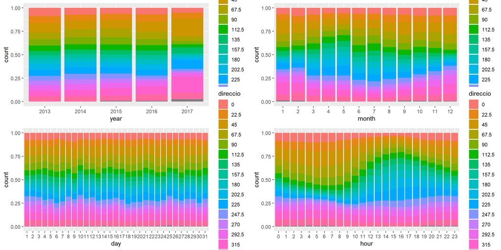

```r
p1<-ggplot(dades,aes(x=year,fill=direccio))+geom_bar(position="fill")
p2<-ggplot(dades,aes(x=month,fill=direccio))+geom_bar(position="fill")
p3<-ggplot(dades,aes(x=day,fill=direccio))+geom_bar(position="fill")
p4<-ggplot(dades,aes(x=hour,fill=direccio))+geom_bar(position="fill")

grid.arrange(p1, p2, p3, p4, ncol=2)
```

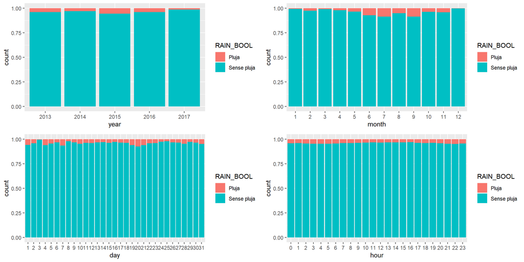

```r
p1<-ggplot(dades,aes(x=year,fill=RAIN_BOOL))+geom_bar(position="fill")
p2<-ggplot(dades,aes(x=month,fill=RAIN_BOOL))+geom_bar(position="fill")
p3<-ggplot(dades,aes(x=day,fill=RAIN_BOOL))+geom_bar(position="fill")
p4<-ggplot(dades,aes(x=hour,fill=RAIN_BOOL))+geom_bar(position="fill")

grid.arrange(p1, p2, p3, p4, ncol=2)
```

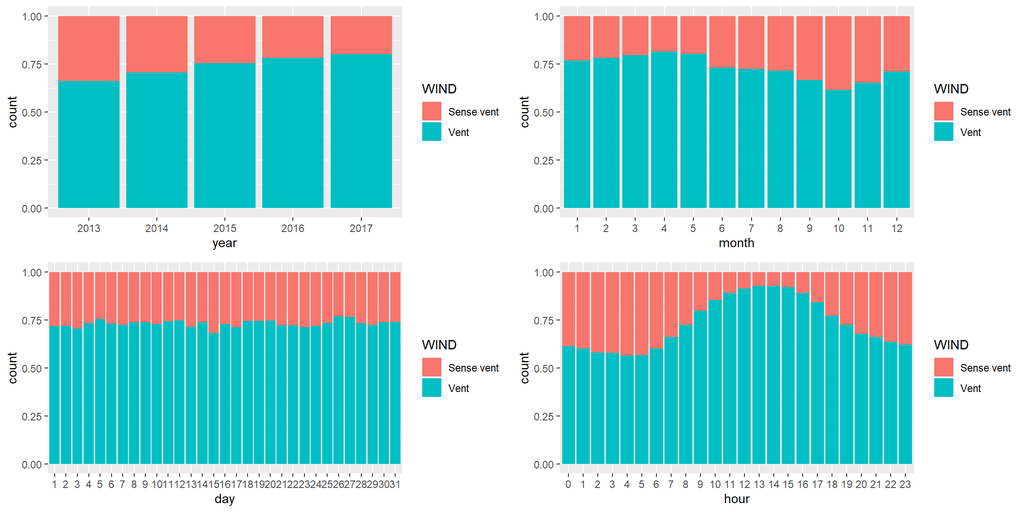

```r
p1<-ggplot(dades,aes(x=year,fill=WIND))+geom_bar(position="fill")
p2<-ggplot(dades,aes(x=month,fill=WIND))+geom_bar(position="fill")
p3<-ggplot(dades,aes(x=day,fill=WIND))+geom_bar(position="fill")
p4<-ggplot(dades,aes(x=hour,fill=WIND))+geom_bar(position="fill")

grid.arrange(p1, p2, p3, p4, ncol=2)
```

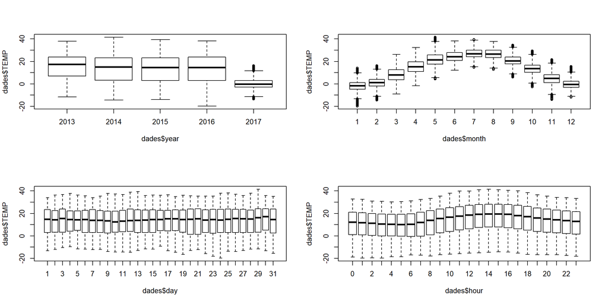

```r
par(mfrow=c(2,2))

p1<-boxplot(dades$TEMP~dades$year)
p2<-boxplot(dades$TEMP~dades$month)
p3<-boxplot(dades$TEMP~dades$day)
p4<-boxplot(dades$TEMP~dades$hour)
```

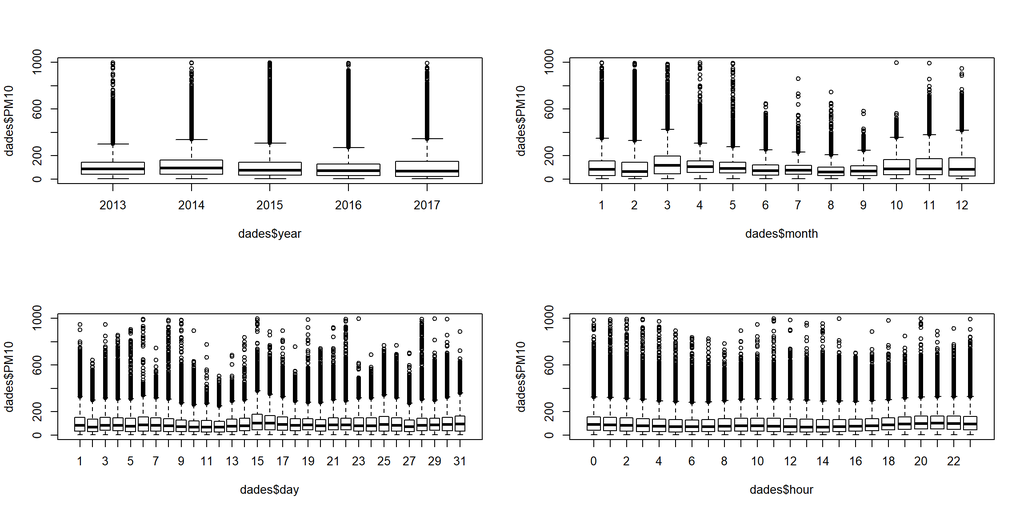

```r
par(mfrow=c(2,2))
p1<-boxplot(dades$PM10~dades$year)
p2<-boxplot(dades$PM10~dades$month)
p3<-boxplot(dades$PM10~dades$day)
p4<-boxplot(dades$PM10~dades$hour)
```

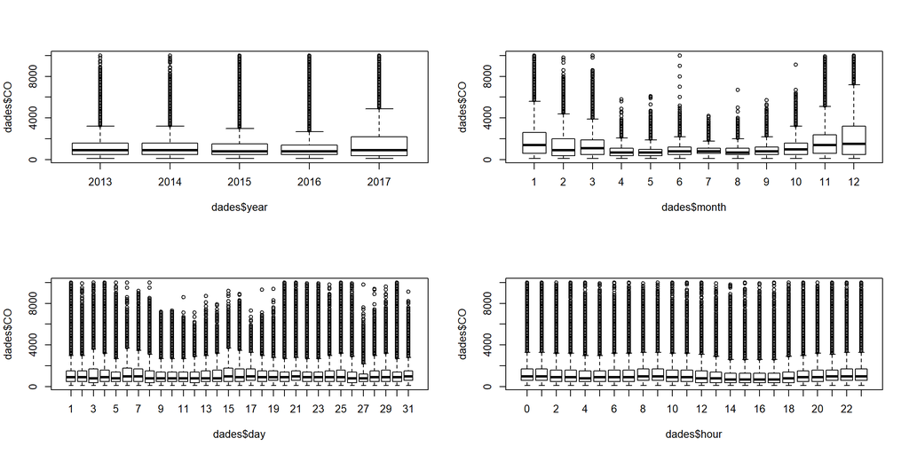

```r
par(mfrow=c(2,2))
p1<-boxplot(dades$CO~dades$year)
p2<-boxplot(dades$CO~dades$month)
p3<-boxplot(dades$CO~dades$day)
p4<-boxplot(dades$CO~dades$hour)
```

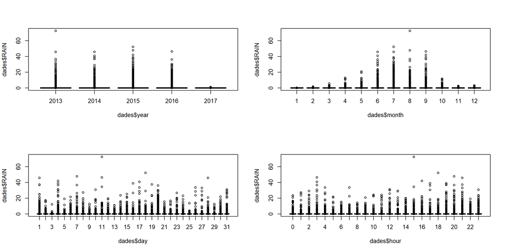

```r
par(mfrow=c(2,2))
p1<-boxplot(dades$RAIN~dades$year)
p2<-boxplot(dades$RAIN~dades$month)
p3<-boxplot(dades$RAIN~dades$day)
p4<-boxplot(dades$RAIN~dades$hour)
```

```r
rm(p1,p2,p3,p4)
```

Observem diversos patrons com:

- El vent bufa generalment del sud i de l’oest a la tarda, mentre que als matins ho fa generalment del nord i l’est.
- El vent bufa generalment més durant el dia que no pas durant la nit.
- L’època de precipitacions més forta es dóna en els mesos d’estiu.
- La temperatura és també més alta en els mesos d’estiu.
- La concentració de partícules és generalment més alta en les hores punta del dia i en els mesos d’hivern

### 2.5.2 Exploració dataset reduit amb increments de 24h

Explorem gràficament les dades per a mirar de detectar patrons de conducta.

Primer es busca la dispersió de cadascun dels atributs respecte al temps. Es diferencien els mesos de forma que es pot obserar la distribució per cada any i cada mes.

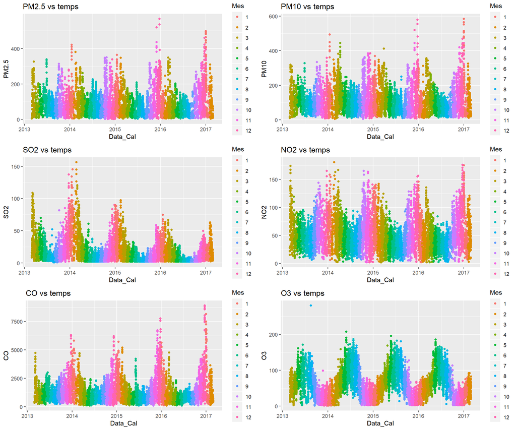

```r
aux <- na.omit(dades.24h)
p1<-ggplot(aux,aes(x=Data_Cal,y=PM2.5, color = as.factor(month(aux$Data_Cal))))+
  geom_point() + ggtitle("PM2.5 vs temps")+ labs(color = "Mes")
p2<-ggplot(aux,aes(x=Data_Cal,y=PM10, color = as.factor(month(aux$Data_Cal)))) +
  geom_point()+ ggtitle("PM10 vs temps")+ labs(color = "Mes")
p3<-ggplot(aux,aes(x=Data_Cal,y=SO2, color = as.factor(month(aux$Data_Cal)))) +
  geom_point()+ ggtitle("SO2 vs temps")+ labs(color = "Mes")
p4<-ggplot(aux,aes(x=Data_Cal,y=NO2, color = as.factor(month(aux$Data_Cal)))) +
  geom_point()+ ggtitle("NO2 vs temps")+ labs(color = "Mes")
p5<-ggplot(aux,aes(x=Data_Cal,y=CO, color = as.factor(month(aux$Data_Cal)))) +
  geom_point()+ ggtitle("CO vs temps")+ labs(color = "Mes")
p6<-ggplot(aux,aes(x=Data_Cal,y=O3, color = as.factor(month(aux$Data_Cal)))) +
  geom_point()+ ggtitle("O3 vs temps")+ labs(color = "Mes")

grid.arrange(p1, p2, p3, p4,p5,p6,ncol=2)
```

```r
rm(p1,p2,p3,p4,p5,p6,aux)
```

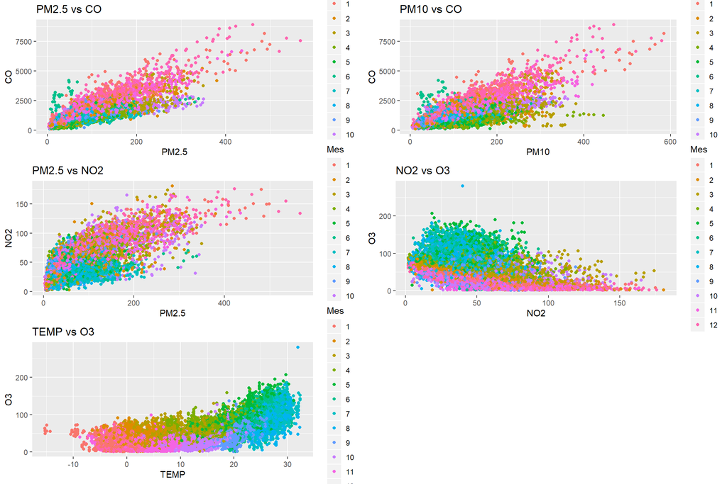

```r
aux <- na.omit(dades.24h)
p1<-ggplot(aux,aes(x=PM2.5,y=CO, color = as.factor(month(aux$Data_Cal))))+
  geom_point() + ggtitle("PM2.5 vs CO")+ labs(color = "Mes")
p2<-ggplot(aux,aes(x=PM10,y=CO, color = as.factor(month(aux$Data_Cal)))) +
  geom_point()+ ggtitle("PM10 vs CO")+ labs(color = "Mes")
p3<-ggplot(aux,aes(x=PM2.5,y=NO2, color = as.factor(month(aux$Data_Cal))))+
  geom_point() + ggtitle("PM2.5 vs NO2")+ labs(color = "Mes")
p4<-ggplot(aux,aes(x=NO2,y=O3, color = as.factor(month(aux$Data_Cal)))) +
  geom_point()+ ggtitle("NO2 vs O3")+ labs(color = "Mes")
p5<-ggplot(aux,aes(x=TEMP,y=O3, color = as.factor(month(aux$Data_Cal)))) +
  geom_point()+ ggtitle("TEMP vs O3")+ labs(color = "Mes")
grid.arrange(p1,p2,p3,p4,p5,ncol=2)
```

```r
rm(p1, p2,p3, p4,p5,aux)
```

S’observa com en funció del mes hi ha un increment dels indicadors, per tant cosiderem important realitzar un estudi de les series temporals per entendre el comportament dels indicadors.

## 2.6 Estudis de la qualitat de l’aire

Observarem la qualiat de l’aire de les mesures a partir de les dades dels indicadors. Segons els estàndards de la qualitat de l’aire https://ec.europa.eu/environment/air/quality/standards.htm els nivells no haurien de superar:

- PM2.5 > 25ug/m3 en mitjana anual
- PM10 > 50ug/m3 en mitjana diaria + 40ug/m3 en mitjana anual

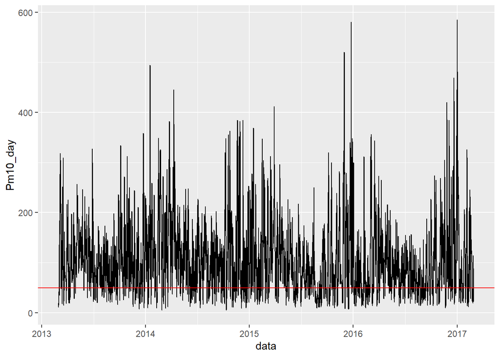

```r
#Omitim valors nuls per a calcular la mitja mòbil
dades2 <- na.omit(dades.24h)

#Calculem la mitja mòbil anual i diària, pels indicadors seleccionats
Pm2.5_year=(rollapply(dades2$PM2.5,365,mean))
Pm10_year=(rollapply(dades2$PM10,365,mean))
Pm10_day=(rollapply(dades2$PM10,1,mean))

#Obtenim els valors corresponents de les dates de la mitja mòbil
dates_anys=dades2$Data_Cal[(365):nrow(dades2)]
dates_dies=dades2$Data_Cal[1:nrow(dades2)]


#Creem 2 datasets per guardar les mitges mòbils diàries i anuals
dades_anuals_mm=data.frame(data=dates_anys,Pm2.5_year,Pm10_year)
dades_diaries_mm=data.frame(data=dates_dies,Pm10_day)


#Dibuixem les dades amb la línia de referència de cada mesura
p<-ggplot(data=dades_diaries_mm,aes(x=data,y=Pm10_day)) + geom_line()
p+geom_hline(yintercept=50, color = "red")
```

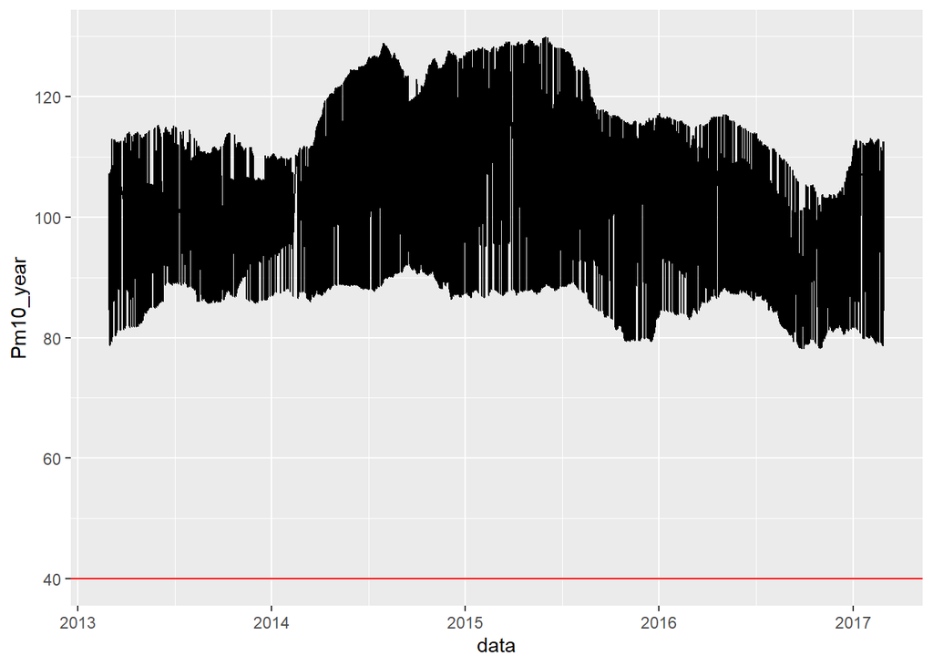

```r
p<-ggplot(data=dades_anuals_mm,aes(x=data,y=Pm10_year)) + geom_line()
p+geom_hline(yintercept=40, color = "red")
```

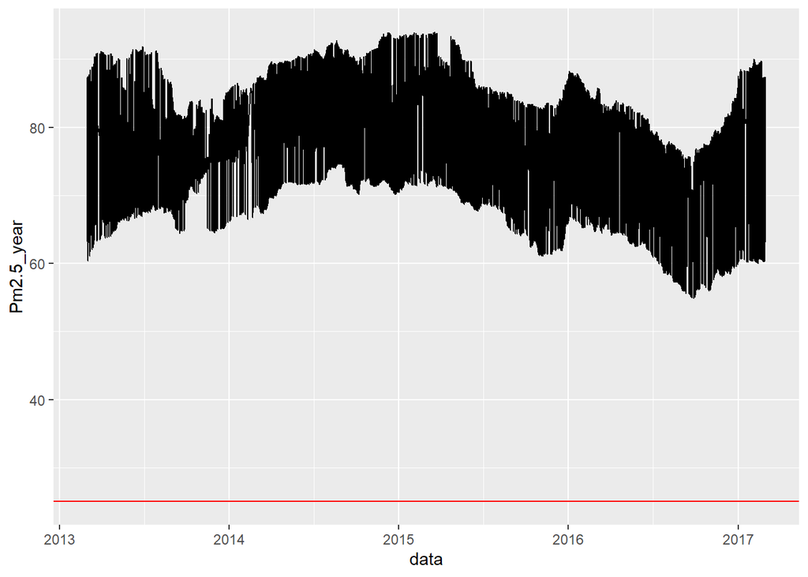

```r
p<-ggplot(data=dades_anuals_mm,aes(x=data,y=Pm2.5_year)) + geom_line()
p+geom_hline(yintercept=25, color = "red")
```

```r
#rm(p,Pm2.5_year,Pm10_year,Pm10_day,dades_anuals_mm,dades_diaries_mm,dates_anys,dates_dies)
```

Observem que les dades mitjanes per any i per dia estan molt per sobre de les recomanades per les autoritats mediambientals.

## 2.7 Estudis efectes principals i interaccions

A continuació estudiarem els efectes principals i les interaccions entre algunes de les variables que observem gràficament que poden ser importants per a l’estudi.

### 2.7.1 Efecte de la direcció del vent en PM10 segons la pluja

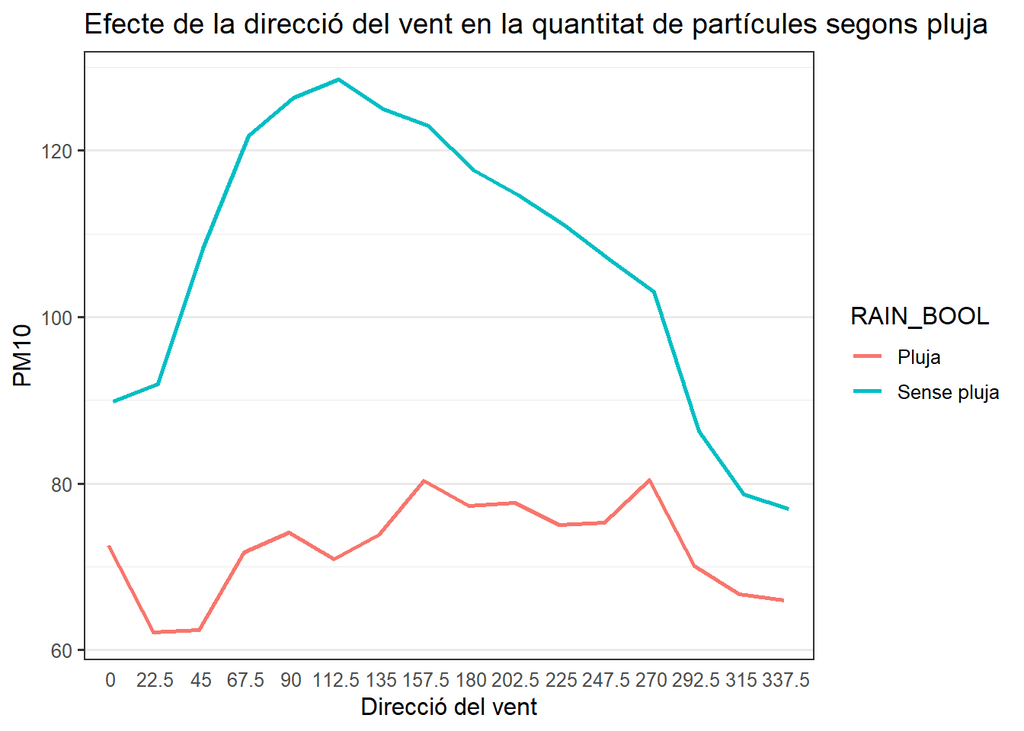

```r
dades2 <- na.omit(dades)
taula_resum=summarise_at(group_by(dades2,direccio,RAIN_BOOL),vars(PM10),list(mean))

ggplot(taula_resum, aes(x = direccio, y = PM10, fill = RAIN_BOOL)) +
    stat_summary(aes(group = RAIN_BOOL, color = RAIN_BOOL), fun = "mean", geom = "line",
                 position = position_dodge(.2), size = 1) +
    labs(title = "Efecte de la direcció del vent en la quantitat de partícules segons pluja",
         x = "Direcció del vent", y = "PM10") +
    theme_bw(base_size = 12) +
    theme(panel.grid.major.x = element_blank(),
          axis.ticks.x = element_blank())
```

El gràfic resultant ens permet interpretar que la direcció del vent té efecte sobre la concentració de PM10 (ja que les línies no son horitzontals) i que la pluja també en té (ja que les línies no se superposen). Adicionalment als efectes principals, el gràfic ens permet afirmar que les variables presenten interacció entre elles, ja que les línies no son paral·leles. Clarament, quan plou, la direcció del vent no és tan important per determinar la concentració de partícules.

### 2.7.2 Efecte de la direcció del vent en PM10 segons l’estació de l’any

Repetim l’estudi segons l’estació de l’any.

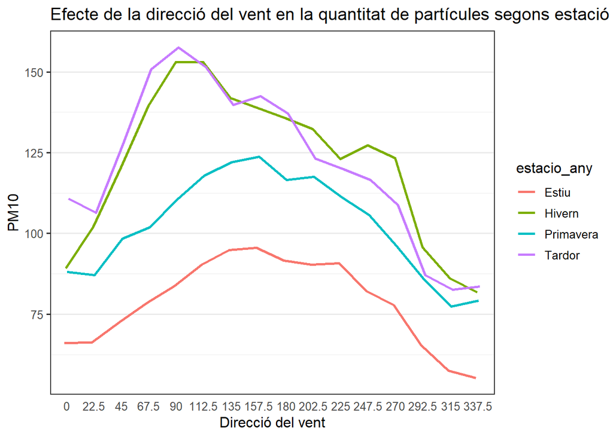

```r
dades2 <- na.omit(dades)
taula_resum=summarise_at(group_by(dades2,direccio,estacio_any),vars(PM10),list(mean))

ggplot(taula_resum, aes(x = direccio, y = PM10, fill = estacio_any)) +
    stat_summary(aes(group = estacio_any, color = estacio_any), fun = "mean", geom = "line",
                 position = position_dodge(.2), size = 1) +
    labs(title = "Efecte de la direcció del vent en la quantitat de partícules segons estació any",
         x = "Direcció del vent", y = "PM10") +
    theme_bw(base_size = 12) +
    theme(panel.grid.major.x = element_blank(),
          axis.ticks.x = element_blank())
```

```r
rm(taula_resum)
```

El gràfic resultant ens confirma la dependència de la quantitat de partícules segons la direcció del vent així com de l’estació de l’any. Adicionalment el gràfic ens permet afirmar que les variables no presenten interacció entre elles, ja que les línies guarden un cert paral·lelisme.

# 3. Neteja de les dades.

## 3.1. Les dades contenen zeros o elements buits? Com gestionaries aquests casos?

En aquest cas les dades quantitatives poden contenir el valor 0 degut a que corresponen a temperatures, precipitacions i densitats. Per tant, els valors perduts s’indiquen amb el valor *NaN* o *Not a Number*.

El primer pas és localitzar els valors perduts. Per això es mostra a continuació el nombre de valors perduts per cada atribut.

Per el dataset sencer:

```r
valors_perduts=colSums(is.na(dades))
valors_perduts
```

```
##          No        year       month         day        hour       PM2.5
##           0           0           0           0           0        8739
##        PM10         SO2         NO2          CO          O3        TEMP
##        6449        9021       12116       20701       13277         398
##        PRES        DEWP        RAIN          wd        WSPM     station
##         393         403         390        1822         318           0
##   RAIN_BOOL        WIND    direccio    Data_Cal estacio_any
##           0           0        1822           0           0
```

Per el dataset de 24h:

```r
valors_perduts.24h=colSums(is.na(dades.24h))
valors_perduts.24h
```

```
##    PM2.5     PM10      SO2      NO2       CO       O3     TEMP     PRES
##     2388     1959     2472     3240     4001     3912      188      189
##     RAIN     WSPM direccio  station Data_Cal
##      192      151     1101        0        0
```

Hi han múltiples opcions per tractar els valors perduts:

- Eliminar les instàncies que continguin valors perduts.
- Substituir els valors perduts amb la mitja o media del atribut.
- Aplicar model numèric per trobar els valors possibles.

En el cas d’eliminar les instàncies amb valors *NaN* ho fariem com:

```r
dades.na_omited <- na.omit(dades)
```

Agrupem les dades perdudes per hora i per mes. Observem que estan aproximadament distribuïdes per totes les categories.

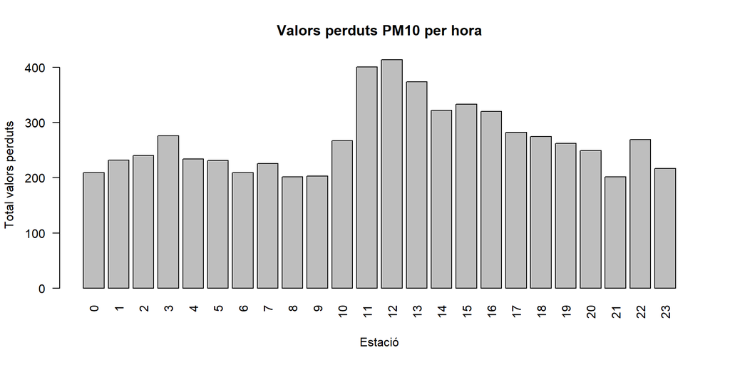

```r
#Exemple valors perduts per PM10
dades_perdudes_PM10=subset(dades,is.na(dades$PM10))

barplot(tapply(dades_perdudes_PM10$PM10,dades_perdudes_PM10$hour,length),las=2,xlab = "Estació",ylab="Total valors perduts",main="Valors perduts PM10 per hora")
```

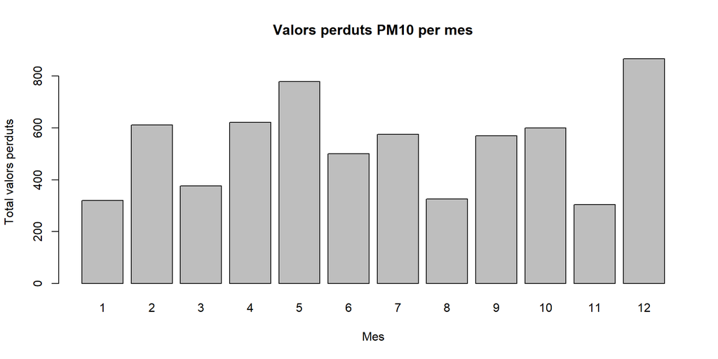

```r
barplot(tapply(dades_perdudes_PM10$PM10,dades_perdudes_PM10$month,length),xlab = "Mes",ylab="Total valors perduts",main="Valors perduts PM10 per mes")
```

```r
rm(dades_perdudes_PM10)
```

## 3.2. Identificació i tractament de valors extrems.

Identifiquem els valors extrems de les variables i els deixem com *NaN*.

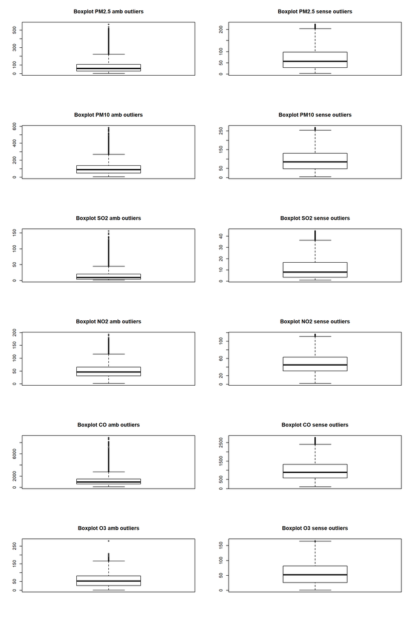

```r
#PENDENT: Quin tractament es fa als valors extrems??

remove_outliers <- function(x, na.rm = TRUE, ...) {
  qnt <- quantile(x, probs=c(.25, .75), na.rm = na.rm, ...)
  H <- 1.5 * IQR(x, na.rm = na.rm)
  y <- x
  y[x < (qnt[1] - H)] <- NA
  y[x > (qnt[2] + H)] <- NA
  y
}

dades3 <- dades.24h
atributs <- c("PM2.5","PM10","SO2","NO2","CO","O3")

for(i in atributs){
  dades3[[i]]<-remove_outliers(dades.24h[[i]])
}

aux.24h <- dades3

par(mfrow=c(6,2))

# PM2.5
boxplot(dades.24h$PM2.5, main="Boxplot PM2.5 amb outliers")
boxplot(dades3$PM2.5, main="Boxplot PM2.5 sense outliers")
# PM10
boxplot(dades.24h$PM10, main="Boxplot PM10 amb outliers")
boxplot(dades3$PM10, main="Boxplot PM10 sense outliers")
# SO2
boxplot(dades.24h$SO2, main="Boxplot SO2 amb outliers")
boxplot(dades3$SO2, main="Boxplot SO2 sense outliers")
# NO2
boxplot(dades.24h$NO2, main="Boxplot NO2 amb outliers")
boxplot(dades3$NO2, main="Boxplot NO2 sense outliers")
# CO
boxplot(dades.24h$CO, main="Boxplot CO amb outliers")
boxplot(dades3$CO, main="Boxplot CO sense outliers")
# O3
boxplot(dades.24h$O3, main="Boxplot O3 amb outliers")
boxplot(dades3$O3, main="Boxplot O3 sense outliers")
```

```r
rm(atributs,i)
```

### 3.3 Estimació valors perduts per al set de dades reduit

```r
stations=unique(aux.24h$station)
hours=unique(aux.24h$hour)
total_station=length(stations)
total_hour=length(hours)

#Seleccionem 7 de les variables "month","hour","station","PM10","PM2.5","wd" i "WSPM".
attibuts <- c("PM2.5","PM10","SO2","NO2","CO","O3","station","Data_Cal")
dades_sample <- aux.24h[attibuts]
dades.24hmod <- aux.24h
for (i in 1:total_station){
    subset=subset(dades_sample,dades_sample$station==stations[i])
    dades_imp_i=kNN(subset,k=3)
    dades.24hmod$PM10[dades_sample$station==stations[i]]=dades_imp_i$PM10
    dades.24hmod$PM2.5[dades_sample$station==stations[i]]=dades_imp_i$PM2.5
    dades.24hmod$SO2[dades_sample$station==stations[i]]=dades_imp_i$SO2
    dades.24hmod$NO2[dades_sample$station==stations[i]]=dades_imp_i$NO2
    dades.24hmod$CO[dades_sample$station==stations[i]]=dades_imp_i$CO
    dades.24hmod$O3[dades_sample$station==stations[i]]=dades_imp_i$O3

    #print(stations[i])
}
dades.24hmod$mes <- as.numeric(month(dades.24hmod$Data_Cal))
dades.24hmod$year <- as.numeric(year(dades.24hmod$Data_Cal))


rm(hours,i,stations,total_hour,total_station,subset,dades_imp_i,attibuts,dades_sample)
```

```r
write.csv(dades,"Dades_modificades.csv")
write.csv(dades.24h,"Dades_modificades_24h.csv")
```

# 4. Anàlisi de les dades.

## 4.1. Selecció dels grups de dades que es volen analitzar/comparar (planificació dels anàlisis a aplicar).

Per poder realitzar el seguit de proves estadístiques, es determina el set de dades amb el qual es treballa.

En aquest cas es tria el set de dades reduides en mostres diaries per reduir de forma considerable el volum de informació amb el qual es treballa, i un cop s’han tractat els seus valors extrems i valors *NaN*.

```r
#Es mostra el set de dades reduides amb el qual es treballaran les proves estadístiques
summary(dades.24hmod)
```

```
##      PM2.5             PM10              SO2              NO2
##  Min.   :  3.00   Min.   :  4.833   Min.   : 1.000   Min.   :  2.00
##  1st Qu.: 33.33   1st Qu.: 52.667   1st Qu.: 4.125   1st Qu.: 32.17
##  Median : 65.83   Median : 94.062   Median : 9.333   Median : 46.33
##  Mean   : 80.93   Mean   :106.792   Mean   :12.690   Mean   : 50.78
##  3rd Qu.:118.25   3rd Qu.:151.052   3rd Qu.:18.958   3rd Qu.: 67.04
##  Max.   :223.08   Max.   :268.292   Max.   :44.667   Max.   :116.33
##
##        CO               O3              TEMP              PRES
##  Min.   : 100.0   Min.   :  1.00   Min.   :-15.683   Min.   : 985.8
##  1st Qu.: 658.3   1st Qu.: 27.54   1st Qu.:  3.221   1st Qu.:1002.2
##  Median : 983.3   Median : 52.29   Median : 15.129   Median :1010.4
##  Mean   :1134.7   Mean   : 57.42   Mean   : 13.628   Mean   :1010.7
##  3rd Qu.:1487.5   3rd Qu.: 82.12   3rd Qu.: 23.533   3rd Qu.:1018.8
##  Max.   :2779.2   Max.   :165.71   Max.   : 32.367   Max.   :1041.0
##                                    NA's   :188       NA's   :189
##       RAIN               WSPM            direccio             station
##  Min.   : 0.00000   Min.   :0.1708   163.125 :  148   Aotizhongxin:1461
##  1st Qu.: 0.00000   1st Qu.:1.1917   146.25  :  143   Changping   :1461
##  Median : 0.00000   Median :1.5542   143.4375:  140   Dingling    :1461
##  Mean   : 0.06444   Mean   :1.7262   144.375 :  138   Dongsi      :1461
##  3rd Qu.: 0.00000   3rd Qu.:2.0542   170.625 :  138   Guanyuan    :1461
##  Max.   :11.10833   Max.   :7.2375   (Other) :15724   Gucheng     :1461
##  NA's   :192        NA's   :151      NA's    : 1101   (Other)     :8766
##     Data_Cal               mes              year
##  Min.   :2013-03-01   Min.   : 1.000   Min.   :2013
##  1st Qu.:2014-03-01   1st Qu.: 4.000   1st Qu.:2014
##  Median :2015-03-01   Median : 7.000   Median :2015
##  Mean   :2015-03-01   Mean   : 6.523   Mean   :2015
##  3rd Qu.:2016-02-29   3rd Qu.:10.000   3rd Qu.:2016
##  Max.   :2017-02-28   Max.   :12.000   Max.   :2017
##
```

Abans de poder determinar quin tipus d’analisi es vol desenvolupar, cal primer estudiar la distribució de cadascun dels atributs que conformen el data set i la seva variança. En funció dels resultats obtinguts es determina quin tipus d’estudi escau millor.

## 4.2. Comprovació de la normalitat i homogeneïtat de la variància.

Es defineix una variable amb els noms dels atributs.

```r
atributs <- c("PM2.5","PM10","SO2","NO2","CO","O3")
```

### 4.2.1 Comprovació normalitat

Es comprova de forma no parametrica la distribució normal de les dades.

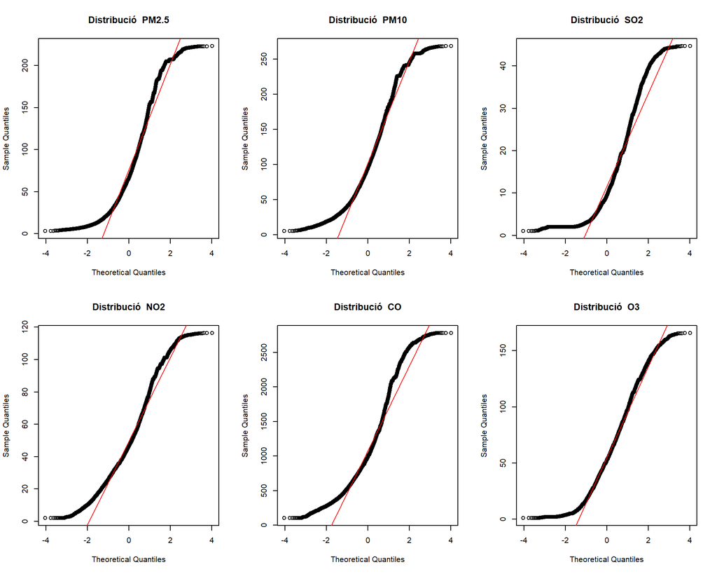

```r
# Visualització de la distribució de les dades en funció de cada atribut
par(mfrow=c(2,3))

for(i in atributs){
  qqnorm(dades.24hmod[[i]], main=paste("Distribució ",i))
  qqline(dades.24hmod[[i]],col=2)
}
```

Com s’observa en les gràfiques, els esmentats atributs no compleixen la distribució normal. Tot i això ho acompanyem del test pertinent. Per realitzar la prova, es fa ús de la funció *Anderson-Darling*. Aquesta funció permet estudiar la supossada distribució normal dels atributs sense límit de mostres. Com en aquest cas es té una gran quantitat d’instàncies, caldrà fer ús d’aquesta funció.

```r
for(i in atributs){
  aux <-ad.test(dades.24hmod[[i]])
  print(paste("Per l'atribut",i,"s'obté el valor p:", aux$p.value))
}
```

```
## [1] "Per l'atribut PM2.5 s'obté el valor p: 3.7e-24"
## [1] "Per l'atribut PM10 s'obté el valor p: 3.7e-24"
## [1] "Per l'atribut SO2 s'obté el valor p: 3.7e-24"
## [1] "Per l'atribut NO2 s'obté el valor p: 3.7e-24"
## [1] "Per l'atribut CO s'obté el valor p: 3.7e-24"
## [1] "Per l'atribut O3 s'obté el valor p: 3.7e-24"
```

Tant amb els gràfics com amb els calculs de *Anderson-Darling*, s’obté que no es compleix la distribució de normalitat.

En cas de voler realitzar proves estadístiques que requereixin condició de normalitat, hi ha un conjunt de funcions *BOXCOX* que permeten transformar les dades i obenir així una distribució normal d’aquestes. Per ara no s’implementa.

### 4.2.2 Comprovació homogeneitat variables

A continuació s’estudia la homogeneiat de les dades, per poder procedir s’ha de tenir en compte que les dades no tenen una distribució normal, per aquest motiu s’estudiara segons *Fligner-Killeen*.

Es busca comprovar si les variances dels diferents atributs són iguals en funció de la estació de mesura.

```r
for(i in atributs){
  aux <-fligner.test(dades.24hmod[[i]],dades.24hmod$station)
  print(paste("Per l'atribut",i,"en funció de l'estació de mesura s'obté el valor p:", aux$p.value))
}
```

```
## [1] "Per l'atribut PM2.5 en funció de l'estació de mesura s'obté el valor p: 5.49870808535529e-26"
## [1] "Per l'atribut PM10 en funció de l'estació de mesura s'obté el valor p: 1.93385524360678e-27"
## [1] "Per l'atribut SO2 en funció de l'estació de mesura s'obté el valor p: 3.95858216797367e-118"
## [1] "Per l'atribut NO2 en funció de l'estació de mesura s'obté el valor p: 3.26724309075305e-91"
## [1] "Per l'atribut CO en funció de l'estació de mesura s'obté el valor p: 9.14729924095079e-46"
## [1] "Per l'atribut O3 en funció de l'estació de mesura s'obté el valor p: 1.05805188990386e-41"
```

En aquest cas, es rebutja la hipòtesi nul·la d’homoscedasticitat degut a que el valor p és menor a index de significancia fixat com a 0.05 (5%), i es conclou que les diferents variables presenten variàncies estadísticament diferents per als diferents grups de *station*.

Es torna a calcular, però en aquest cas per múltiples aributs en funció de l’any. S’obté el mateix resultat, es segueix rebutjant la hipòtesi nul·la d’homoscedasticitat.

```r
for(i in atributs){
  aux <-fligner.test(dades.24hmod[[i]],dades.24hmod$year)
  print(paste("Per l'atribut",i,"en funció de l'any s'obté el valor p:", aux$p.value))
}
```

```
## [1] "Per l'atribut PM2.5 en funció de l'any s'obté el valor p: 3.1268308487937e-24"
## [1] "Per l'atribut PM10 en funció de l'any s'obté el valor p: 1.00974026504249e-33"
## [1] "Per l'atribut SO2 en funció de l'any s'obté el valor p: 9.01397300507541e-73"
## [1] "Per l'atribut NO2 en funció de l'any s'obté el valor p: 7.82608981529802e-14"
## [1] "Per l'atribut CO en funció de l'any s'obté el valor p: 3.0297842376957e-15"
## [1] "Per l'atribut O3 en funció de l'any s'obté el valor p: 4.31858286717401e-46"
```

## 4.3. Aplicació de proves estadístiques al grup de dades.

### a) Comparció de les mitjanes dels grups

Amb l’objectiu de comparar si les mitajes dels diferents index que permeten quantificar la qualitat de l’aire varien en funció de l’estació de mesura, es realitza el següent estudi.

Com que els atributs no tenen una distribució normal i no tenen variancia constant en funció de l’estació de mesura es realitza l’estudi segons *Kruskal*.

```r
aux <- dades.24hmod
aux$station <- as.numeric(aux$station)
for(i in atributs){
  rs <-kruskal.test(aux[[i]],aux$station)
  print(paste("Per l'atribut",i,"en funció de l'estació de mesura s'obté el valor p:", rs$p.value))
}
```

```
## [1] "Per l'atribut PM2.5 en funció de l'estació de mesura s'obté el valor p: 8.91174286275296e-32"
## [1] "Per l'atribut PM10 en funció de l'estació de mesura s'obté el valor p: 3.25054226333787e-54"
## [1] "Per l'atribut SO2 en funció de l'estació de mesura s'obté el valor p: 1.80216680322492e-100"
## [1] "Per l'atribut NO2 en funció de l'estació de mesura s'obté el valor p: 0"
## [1] "Per l'atribut CO en funció de l'estació de mesura s'obté el valor p: 9.35570065882068e-131"
## [1] "Per l'atribut O3 en funció de l'estació de mesura s'obté el valor p: 2.5098548084582e-108"
```

Es conclou que presenta mitjanes diferents per a cadascun dels atributs en funció de l’estació de mesura.

Es realitza el mateix test en funció del mateixos atributs i l’any.

```r
for(i in atributs){
  rs <-kruskal.test(aux[[i]],aux$year)
  print(paste("Per l'atribut",i,"en funció de l'any de mesura s'obté el valor p:", rs$p.value))
}
```

```
## [1] "Per l'atribut PM2.5 en funció de l'any de mesura s'obté el valor p: 6.15032777231488e-19"
## [1] "Per l'atribut PM10 en funció de l'any de mesura s'obté el valor p: 1.45696262721095e-43"
## [1] "Per l'atribut SO2 en funció de l'any de mesura s'obté el valor p: 2.38299812106825e-225"
## [1] "Per l'atribut NO2 en funció de l'any de mesura s'obté el valor p: 1.04019937344782e-46"
## [1] "Per l'atribut CO en funció de l'any de mesura s'obté el valor p: 2.05020053411346e-22"
## [1] "Per l'atribut O3 en funció de l'any de mesura s'obté el valor p: 5.4693443812667e-27"
```

Es conclou que presenta mitjanes diferents per a cadascun dels atributs en funció de l’any de mesura.

### b) Correlació entre atributs

Es vol entendre quina relació hi ha entre les diferents variables qe conformen el ataset d’estudi, per fer-ho, es realitza un estudi de correlació. Com que les dades no tenen una distribució normal, el mètode de càlcul serà *Spearman*.

A continuació es mostra la correlació entre atributs numèrics:

```r
atributs.numerics <- c("PM2.5","PM10","SO2","NO2","CO","O3","mes","year")
cor(dades.24hmod[atributs.numerics],method = "spearman")
```

```
##              PM2.5        PM10        SO2         NO2          CO
## PM2.5  1.000000000  0.91109059  0.4667014  0.64247215  0.81866217
## PM10   0.911090590  1.00000000  0.5001963  0.66626466  0.73317355
## SO2    0.466701384  0.50019626  1.0000000  0.59868494  0.59893387
## NO2    0.642472145  0.66626466  0.5986849  1.00000000  0.74595221
## CO     0.818662169  0.73317355  0.5989339  0.74595221  1.00000000
## O3    -0.159319918 -0.11786679 -0.3436336 -0.51275756 -0.44334778
## mes   -0.004928792 -0.04087494 -0.1792245  0.04457053  0.04954504
## year  -0.038393067 -0.05692311 -0.1763120 -0.06819021 -0.05411777
##                O3          mes        year
## PM2.5 -0.15931992 -0.004928792 -0.03839307
## PM10  -0.11786679 -0.040874941 -0.05692311
## SO2   -0.34363358 -0.179224544 -0.17631197
## NO2   -0.51275756  0.044570527 -0.06819021
## CO    -0.44334778  0.049545036 -0.05411777
## O3     1.00000000 -0.163617631 -0.02516307
## mes   -0.16361763  1.000000000 -0.18474601
## year  -0.02516307 -0.184746007  1.00000000
```

Una altra manera més clarificadora de veure-ho es:

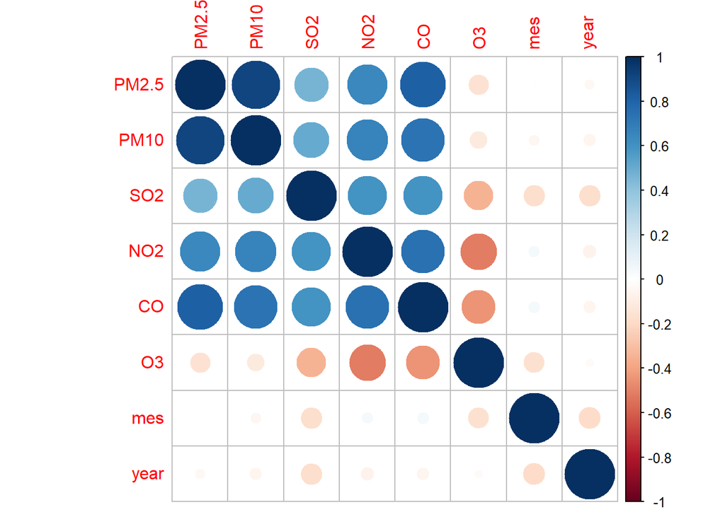

```r
corr <- cor(dades.24hmod[atributs.numerics],method = "spearman")
corrplot(corr, method="circle")
```

S’observa com entre els atributs **PM2.5**, **PM10**, **SO2**, **NO2** i **CO2**, hi ha una correlació possitiva. Encanvi, aquests mateixos atributs amb **O3**, tenen una correlació negativa. El mes i l’any no tenen una forta correlació amb la resta d’atributs.

En aquest cas concret s’estudia el grau de corelació entre els atributs **PM2.5** i **PM0**.

```r
cor.test(dades.24hmod$PM2.5,dades.24hmod$PM10,method="spearman", exact=F)
```

```
##
##  Spearman's rank correlation rho
##
## data:  dades.24hmod$PM2.5 and dades.24hmod$PM10
## S = 7.9853e+10, p-value < 2.2e-16
## alternative hypothesis: true rho is not equal to 0
## sample estimates:
##       rho
## 0.9110906
```

S’observa com el valor p ens fa ebutjar la hipòtesi nul·la descartant que la correlacio sigui 0 (no correlació) i el valor *ro* és proper a 1. Per tan es confirma una forta correlació, això unit a que es coneix que hi ha una correació positiva ens determina que quan un dels ds atributs creix l’altre també.

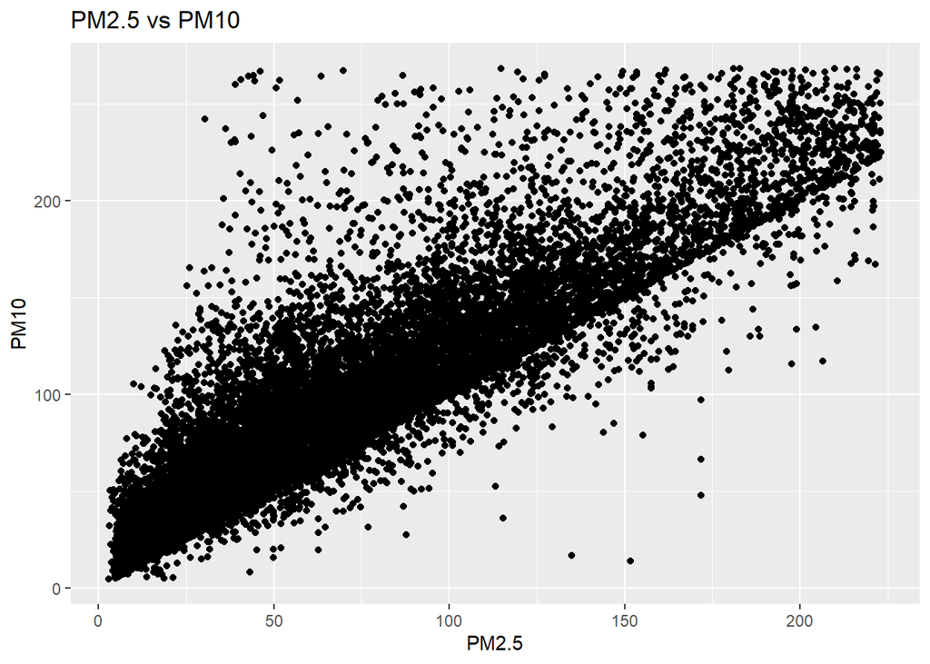

```r
ggplot(dades.24hmod,aes(x=PM2.5,y=PM10, ))+
geom_point() + ggtitle("PM2.5 vs PM10")
```

Aquest anàlisi es pot realitzar per a tots els atributs que es mostren. Nosaltres h farem també per l’atribut *O3* que ens interessa en el següent apartat.

```r
cor.test(dades.24hmod$PM2.5,dades.24hmod$O3,method="spearman", exact=F)
```

```
##
##  Spearman's rank correlation rho
##
## data:  dades.24hmod$PM2.5 and dades.24hmod$O3
## S = 1.0412e+12, p-value < 2.2e-16
## alternative hypothesis: true rho is not equal to 0
## sample estimates:
##        rho
## -0.1593199
```

Si es compara **O3** amb l’atribut **mes** obtenim que els resultats tampoc són gaire concloents. Es a dir, exiteix correlació però és molt baixa i és inferior a +- 0.5.

```r
cor.test(dades.24hmod$mes,dades.24hmod$O3,method="spearman", exact=F)
```

```
##
##  Spearman's rank correlation rho
##
## data:  dades.24hmod$mes and dades.24hmod$O3
## S = 1.0451e+12, p-value < 2.2e-16
## alternative hypothesis: true rho is not equal to 0
## sample estimates:
##        rho
## -0.1636176
```

### c) Anàlisi de tendència i estacionalitat

Volem estudiar la tendència i estacionalitat de les dades, per fer-ho farem una reducció d’instàncies o reduirem a una instància per mes i any.

```r
PM2.5 <- aggregate(PM2.5 ~ mes + year+station, dades.24hmod, FUN=mean)
PM10 <- aggregate(PM10 ~ mes + year+station, dades.24hmod, FUN=mean)
SO2 <- aggregate(SO2 ~ mes + year+station, dades.24hmod, FUN=mean)
NO2 <- aggregate(NO2 ~ mes + year+station, dades.24hmod, FUN=mean)
CO <- aggregate(CO ~ mes + year+station, dades.24hmod, FUN=mean)
O3 <- aggregate(O3 ~ mes + year+station, dades.24hmod, FUN=mean)

df.month <- data.frame("PM2.5"=PM2.5$PM2.5 , "PM10"=PM10$PM10, "SO2"=SO2$SO2, "NO2"=NO2$NO2, "CO"=CO$CO, "O3"=O3$O3,"month"=O3$mes,"year" = O3$year,"station" = O3$station)
df.month$date <- make_date(year=O3$year,month = O3$mes)
rm(PM2.5,PM10,SO2,NO2,CO,O3)
```

Es visualitzen de nou els resultats en funció del temps i de l’estació de mesura.

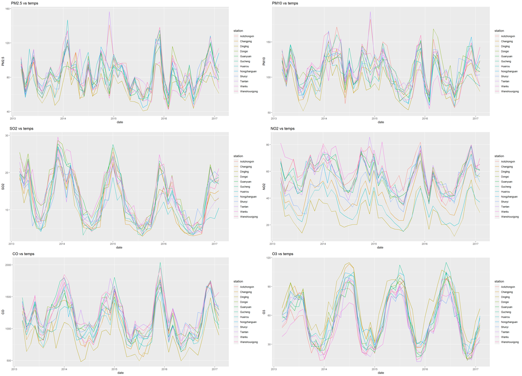

```r
p1<- ggplot(df.month,aes(x=date,y=PM2.5,color = station))+
  geom_line() + ggtitle("PM2.5 vs temps")
p2<- ggplot(df.month,aes(x=date,y=PM10,color = station))+
  geom_line() + ggtitle("PM10 vs temps")
p3<- ggplot(df.month,aes(x=date,y=SO2,color = station))+
  geom_line() + ggtitle("SO2 vs temps")
p4<- ggplot(df.month,aes(x=date,y=NO2,color = station))+
  geom_line() + ggtitle("NO2 vs temps")
p5<- ggplot(df.month,aes(x=date,y=CO,color = station))+
  geom_line() + ggtitle("CO vs temps")
p6<- ggplot(df.month,aes(x=date,y=O3,color = station))+
  geom_line() + ggtitle("O3 vs temps")

grid.arrange(p1, p2, p3, p4,p5,p6,ncol=2)
```

```r
rm(p1,p2,p3,p4,p5,p6)
```

Per simplificar encara més els càlculs, es fa un promig de cada atribut per a totes les estacions i es tracten com a una única estació. A continuació es torna a mostrar les mateixes gràfiques dels diferents atributs.

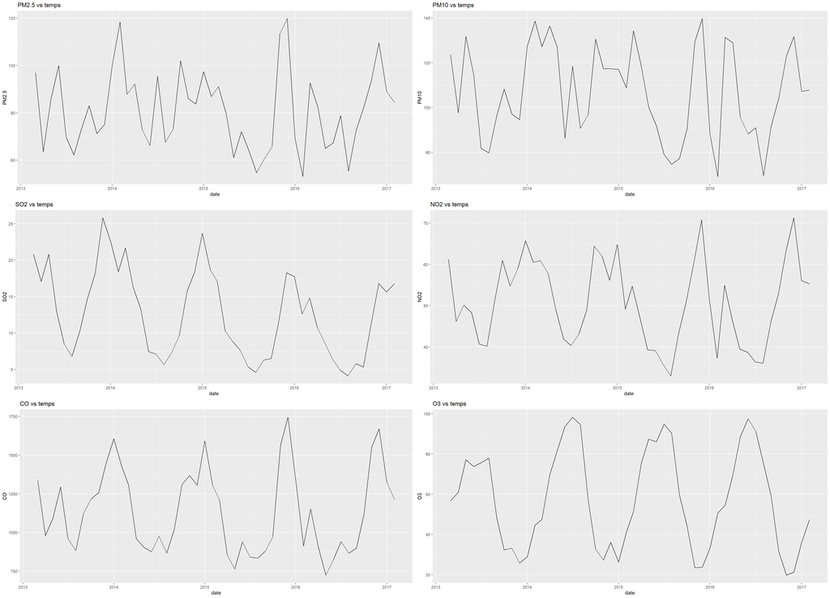

```r
PM2.5 <- aggregate(PM2.5 ~ mes + year, dades.24hmod, FUN=mean)
PM10 <- aggregate(PM10 ~ mes + year, dades.24hmod, FUN=mean)
SO2 <- aggregate(SO2 ~ mes + year, dades.24hmod, FUN=mean)
NO2 <- aggregate(NO2 ~ mes + year, dades.24hmod, FUN=mean)
CO <- aggregate(CO ~ mes + year, dades.24hmod, FUN=mean)
O3 <- aggregate(O3 ~ mes + year, dades.24hmod, FUN=mean)

df.month <- data.frame("PM2.5"=PM2.5$PM2.5 , "PM10"=PM10$PM10, "SO2"=SO2$SO2, "NO2"=NO2$NO2, "CO"=CO$CO, "O3"=O3$O3,"month"=O3$mes,"year" = O3$year)

df.month$date <- make_date(year=O3$year,month = O3$mes)
rm(PM2.5,PM10,SO2,NO2,CO,O3)

p1<- ggplot(df.month,aes(x=date,y=PM2.5))+
  geom_line() + ggtitle("PM2.5 vs temps")
p2<- ggplot(df.month,aes(x=date,y=PM10))+
  geom_line() + ggtitle("PM10 vs temps")
p3<- ggplot(df.month,aes(x=date,y=SO2))+
  geom_line() + ggtitle("SO2 vs temps")
p4<- ggplot(df.month,aes(x=date,y=NO2))+
  geom_line() + ggtitle("NO2 vs temps")
p5<- ggplot(df.month,aes(x=date,y=CO))+
  geom_line() + ggtitle("CO vs temps")
p6<- ggplot(df.month,aes(x=date,y=O3))+
  geom_line() + ggtitle("O3 vs temps")

grid.arrange(p1, p2, p3, p4,p5,p6,ncol=2)
```

```r
rm(p1,p2,p3,p4,p5,p6)
```

De tots aquests atributs, únicament els atributs *SO2* i *O3* semblen que tinguin una certa tendència i periodicitat. S’estudiarà aquests atributs. La resta datributs presenten símptomes de soroll.

Primer es mostra la tendència, estacionaitat i soroll per l’atribut *SO2*.

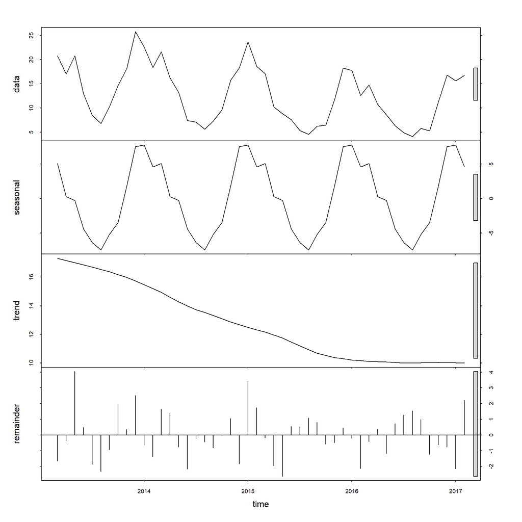

```r
tdf.ts <- ts(df.month$SO2,start = c(2013,3),end=c(2017,2), frequency=12)
monthly_stl <- stl(tdf.ts, s.window = "period")
plot(monthly_stl)
```

Després es mostra la tendència, estacionalitat i soroll per l’atribut *O3*.

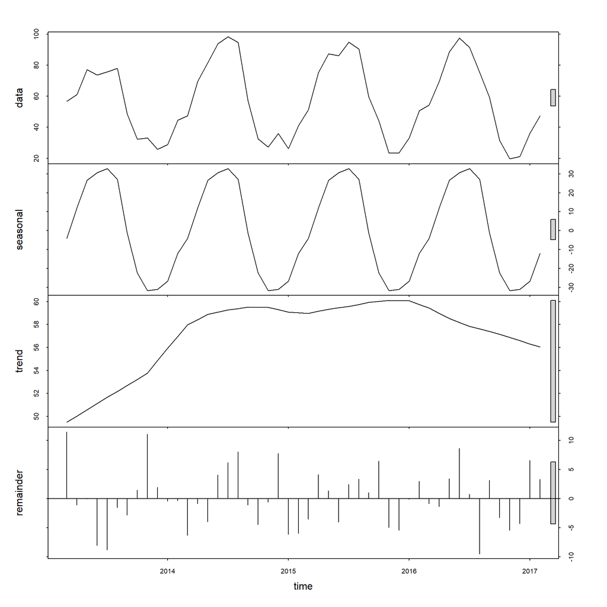

```r
tdf.ts <- ts(df.month$O3,start = c(2013,3),end=c(2017,2), frequency=12)
monthly_stl <- stl(tdf.ts, s.window = "period")
plot(monthly_stl)
```

Per fer això, primer s’esudiarà si les dades tenn una distribució normal:

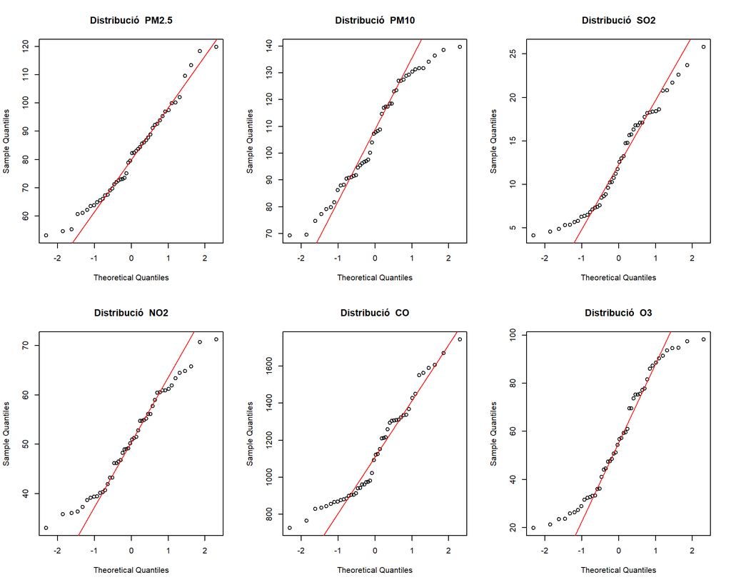

```r
# Visualització de la distribució de les dades en funció de cada atribut
par(mfrow=c(2,3))

for(i in atributs){
  qqnorm(df.month[[i]], main=paste("Distribució ",i))
  qqline(df.month[[i]],col=2)
}
```

S’observa com ara molts atributs semblen que tenen una distribució normal, anem a corroborar-ho amb el test de *Shapiro*.

```r
for(i in atributs){
  aux <-shapiro.test(df.month[[i]])
  print(paste("Per l'atribut",i,"s'obté el valor p:", aux$p.value))
}
```

```
## [1] "Per l'atribut PM2.5 s'obté el valor p: 0.214058222663293"
## [1] "Per l'atribut PM10 s'obté el valor p: 0.0380141250074032"
## [1] "Per l'atribut SO2 s'obté el valor p: 0.0207397132986261"
## [1] "Per l'atribut NO2 s'obté el valor p: 0.213017876956416"
## [1] "Per l'atribut CO s'obté el valor p: 0.00758722813130864"
## [1] "Per l'atribut O3 s'obté el valor p: 0.00797638632360277"
```

S’observa com els atributs *PM2.5* i *NO2* tenen distribucions normals amb una significancia del 5%. En canvi els atributs que volem estudiar *SO2* i *O3* no tenen una distribució normal per una significancia del 5%.

A continuació es calcula la homogeneiat de les dades, per poder procedir s’ha de tenir en compte que les dades no tenen una distribució normal, per aquest motiu s’estudiara segons *Fligner-Killeen*.

```r
# Definició dels atributs a estudiar:
atributs <- c("NO2","O3")

for(i in atributs){
  aux <-fligner.test(df.month[[i]],df.month$year)
  print(paste("Per l'atribut",i,"en funció de l'any de mesura s'obté el valor p:", aux$p.value))
}
```

```
## [1] "Per l'atribut NO2 en funció de l'any de mesura s'obté el valor p: 0.312405142917337"
## [1] "Per l'atribut O3 en funció de l'any de mesura s'obté el valor p: 0.350887635551833"
```

En el cas del mes:

```r
for(i in atributs){
  aux <-fligner.test(df.month[[i]],df.month$month)
  print(paste("Per l'atribut",i,"en funció del mes de mesura s'obté el valor p:", aux$p.value))
}
```

```
## [1] "Per l'atribut NO2 en funció del mes de mesura s'obté el valor p: 0.136113898460868"
## [1] "Per l'atribut O3 en funció del mes de mesura s'obté el valor p: 0.596722245502897"
```

A continuació, es preten treure la tendència d’ambdos atributs de forma manual. Per fer-ho, es calcularà mitjantçant una regressió lineal.

El que es fa és: - 1r: Calcular la tendència de les dades originals - 2n: Extreure la tendència de les dades originals per obtenir l’estacionalitat

A continuació es següeixen aquests passos per *SO2* i *O3*.

```r
# Regressió lineal SO2
reg.SO2 <- lm(SO2~date,df.month)
summary(reg.SO2)
```

```
##
## Call:
## lm(formula = SO2 ~ date, data = df.month)
##
## Residuals:
##     Min      1Q  Median      3Q     Max
## -8.5918 -5.0406 -0.1949  4.7276 10.9756
##
## Coefficients:
##              Estimate Std. Error t value Pr(>|t|)
## (Intercept) 91.768892  31.724445   2.893  0.00582 **
## date        -0.004797   0.001924  -2.493  0.01632 *
## ---
## Signif. codes:  0 '***' 0.001 '**' 0.01 '*' 0.05 '.' 0.1 ' ' 1
##
## Residual standard error: 5.624 on 46 degrees of freedom
## Multiple R-squared:  0.119,  Adjusted R-squared:  0.09988
## F-statistic: 6.215 on 1 and 46 DF,  p-value: 0.01632
```

En aquest cas, s’està estudiant la tendència i estacionalitat de cada atribut per això no te gaire sentit analitzar els coeficients de determinació del resultat de la regressió. El coeficient de determinació indica quin tant percent del model explica la variança de les observacions.

Un cop es te la tendència calculada e procedeix per extreure l’estacionalitat de les dades.

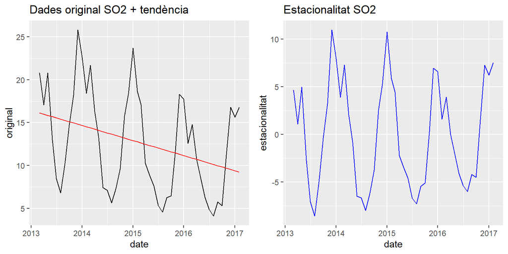

```r
desc.so2 <- data.frame("original"=df.month$SO2,"date"=df.month$date,"tendencia"=reg.SO2$fitted.values)
desc.so2$estacionalitat <- desc.so2$original-desc.so2$tendencia
p1 <- ggplot(desc.so2, aes(x =date, y = original)) + geom_line() + geom_line(color = 'red',data =desc.so2,aes(x=date,y=tendencia))+ ggtitle("Dades original SO2 + tendència")
p2 <- ggplot(desc.so2, aes(x =date, y = estacionalitat)) + geom_line(color="blue") + ggtitle("Estacionalitat SO2")
grid.arrange(p1, p2,ncol=2)
```

```r
rm(p1,p2)
```

Es repeteix el mateix estudi per *O3*.

```r
# Regressió lineal O3
reg.O3 <- lm(O3~date,df.month)
summary(reg.O3)
```

```
##
## Call:
## lm(formula = O3 ~ date, data = df.month)
##
## Residuals:
##     Min      1Q  Median      3Q     Max
## -34.206 -22.413  -2.825  18.867  42.701
##
## Coefficients:
##               Estimate Std. Error t value Pr(>|t|)
## (Intercept) 147.507443 140.889855   1.047    0.301
## date         -0.005470   0.008546  -0.640    0.525
##
## Residual standard error: 24.98 on 46 degrees of freedom
## Multiple R-squared:  0.008828,   Adjusted R-squared:  -0.01272
## F-statistic: 0.4097 on 1 and 46 DF,  p-value: 0.5253
```

Un cop es te la tendència calculada e procedeix per extreure l’estacionalitat de les dades.

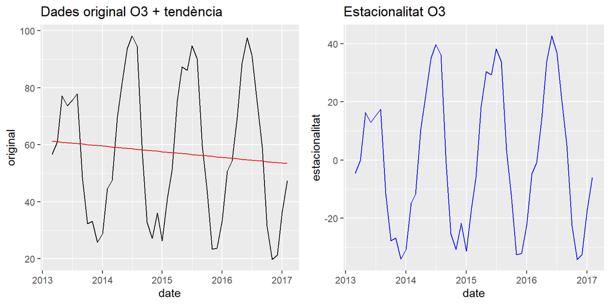

```r
desc.o3 <- data.frame("original"=df.month$O3,"date"=df.month$date,"tendencia"=reg.O3$fitted.values)
desc.o3$estacionalitat <- desc.o3$original-desc.o3$tendencia
p1 <- ggplot(desc.o3, aes(x =date, y = original)) + geom_line() + geom_line(color = 'red',data =desc.o3,aes(x=date,y=tendencia))+ ggtitle("Dades original O3 + tendència")
p2 <- ggplot(desc.o3, aes(x =date, y = estacionalitat)) + geom_line(color="blue")+ ggtitle("Estacionalitat O3")
grid.arrange(p1, p2,ncol=2)
```

```r
rm(p1,p2)
```

Amb l’objectiu de predir el comportament d’aquets atributs basant-nos en els seus valors històrics es genera un model SARIMA. Això es desenvolupa en el següent apartat.

### d) Predicció dels atributs SO2 i O3

El primer pas es dividir el set de dades en set de dades d’entrenament i set de test. Consierem que fins 2016 serà el model de train i a partir de llavors serà el set de dades de test.

```r
train <- df.month[df.month$year<=2015,]
test <- df.month[df.month$year>=2016,]
```

Amb les dades d’entrenament, es calcula la regressió lineal d’aquestes i després es substrau per calcular l’estacionalitat.

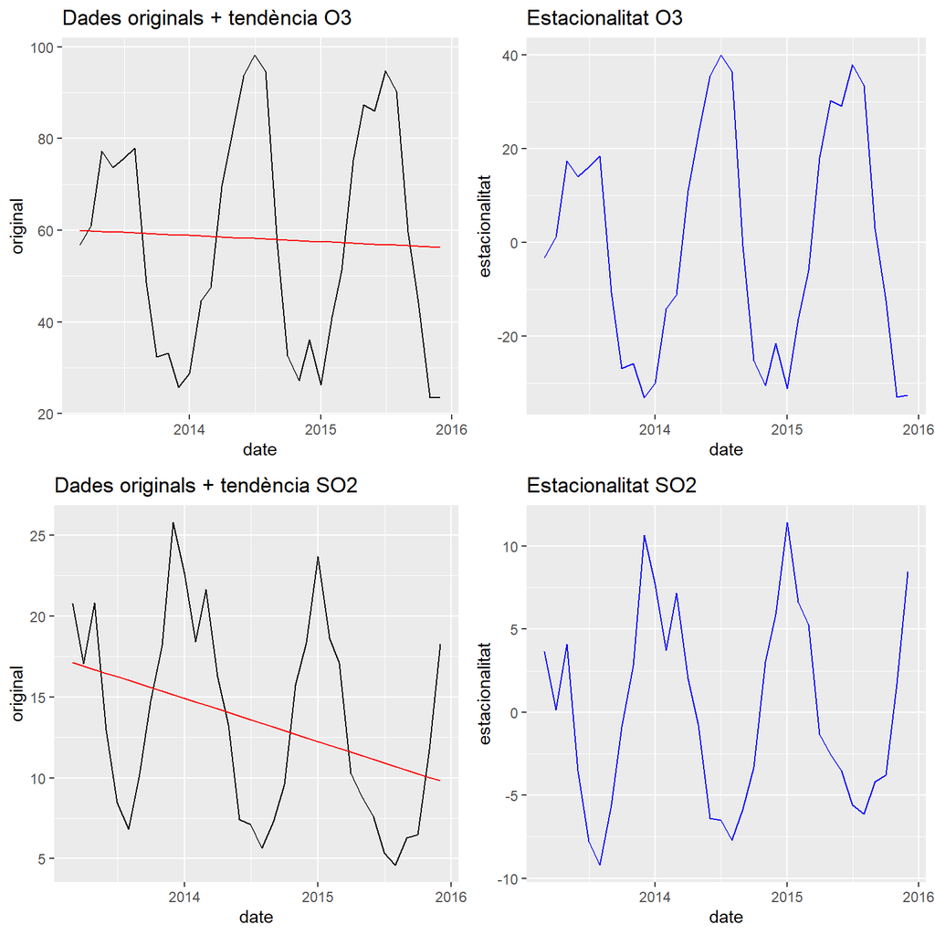

```r
# Regressió lineal SO2
train.SO2 <- lm(SO2~date,train)
# Regressió lineal O3
train.O3 <- lm(O3~date,train)

#
train_desc.o3 <- data.frame("original"=train$O3,"date"=train$date,"tendencia"=train.O3$fitted.values)
train_desc.o3$estacionalitat <- train_desc.o3$original-train_desc.o3$tendencia
#
train_desc.so2 <- data.frame("original"=train$SO2,"date"=train$date,"tendencia"=train.SO2$fitted.values)
train_desc.so2$estacionalitat <- train_desc.so2$original-train_desc.so2$tendencia


p1 <- ggplot(train_desc.o3, aes(x =date, y = original)) + geom_line() + geom_line(color = 'red',data =train_desc.o3,aes(x=date,y=tendencia))+ ggtitle("Dades originals + tendència O3")
p2 <- ggplot(train_desc.o3, aes(x =date, y = estacionalitat)) + geom_line(color="blue")+ ggtitle("Estacionalitat O3")
p3 <- ggplot(train_desc.so2, aes(x =date, y = original)) + geom_line() + geom_line(color = 'red',data =train_desc.so2,aes(x=date,y=tendencia))+ ggtitle("Dades originals + tendència SO2")
p4 <- ggplot(train_desc.so2, aes(x =date, y = estacionalitat)) + geom_line(color="blue")+ ggtitle("Estacionalitat SO2")
grid.arrange(p1, p2,p3,p4,ncol=2)
```

```r
rm(p1,p2,p3,p4)
```

Es busca quin és el model SARIMA que millor ajusta. Aquests models són complexos de calcular, però amb la funció *auto.arima*, et detrmina quin és el que millor ajusta:

```r
# SO2
myts <- ts(train_desc.so2$estacionalitat, start=c(2013,3), end=c(2015,12), frequency=12)
fit.so2 <- auto.arima(myts, seasonal = T)
# O3
myts <- ts(train_desc.o3$estacionalitat, start=c(2013,3), end=c(2015,12), frequency=12)
fit.o3 <- auto.arima(myts, seasonal = T)
```

Es mostren els models SARIMA generats i constrastats amb les dades d’estacionalitat.

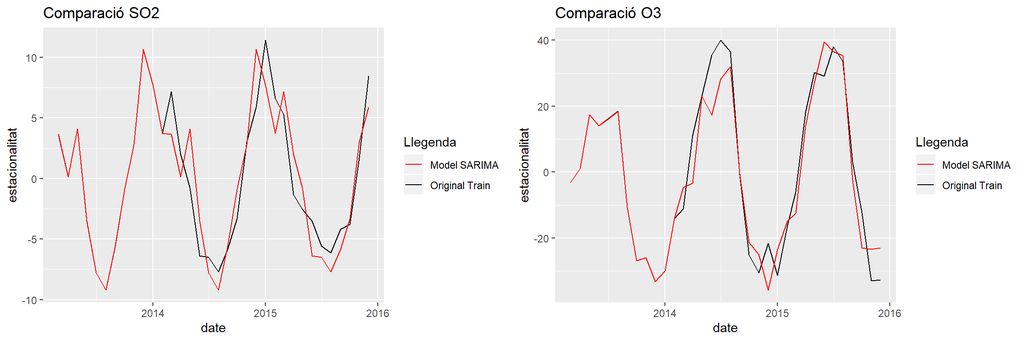

```r
colors <- c("Original Train" = "black", "Model SARIMA" = "red", "Prediccio" = "blue")

aux1 <- data_frame("y"=fit.so2$fitted,"x"=train_desc.so2$date)
aux2 <- data_frame("y"=fit.o3$fitted,"x"=train_desc.o3$date)

p1 <- ggplot(train_desc.so2, aes(x =date, y = estacionalitat)) + geom_line(aes(color="Original Train")) + geom_line(data =aux1,aes(x=x,y=y,color = "Model SARIMA"))+ ggtitle("Comparació SO2")+labs(color = "Llegenda") + scale_color_manual(values = colors)

p2 <- ggplot(train_desc.o3, aes(x =date, y = estacionalitat)) + geom_line(aes(color="Original Train")) + geom_line(data =aux2,aes(x=x,y=y,color = "Model SARIMA"))+ ggtitle("Comparació O3")+labs(color = "Llegenda") +scale_color_manual(values = colors)

grid.arrange(p1, p2,ncol=2)
```

```r
rm(p1,p2)
```

S’observa que entre els models genrats SARIMA i les dades d’estacionalitat originals hi an diferències, no obstant sembla que ajustan força bé.

Es calcula la predicció del models SARIMA.

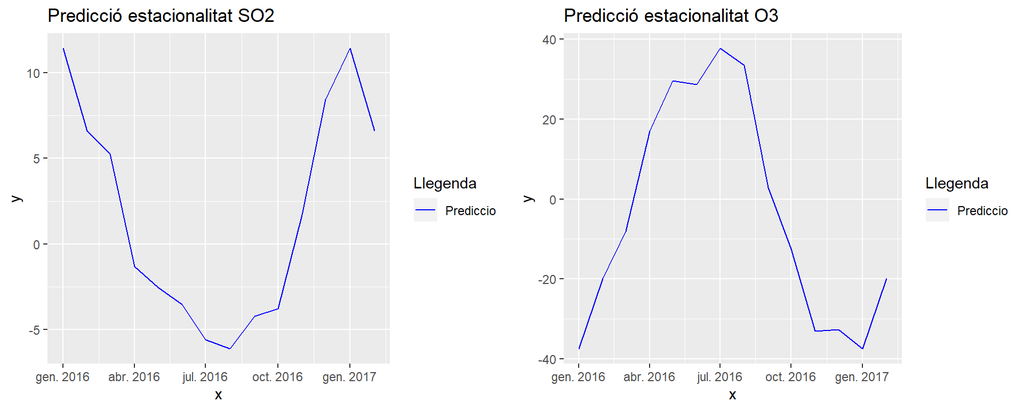

```r
# Es realitza la pedicció
prediction.so2 <- predict(fit.so2,n.ahead = 14)
prediction.o3 <- predict(fit.o3,n.ahead = 14)

# Es guarden els resultats en data frames
aux3 <- data_frame("y"=prediction.so2$pred,"x"=test$date)
aux4 <- data_frame("y"=prediction.o3$pred,"x"=test$date)

p1 <- ggplot(aux3, aes(x =x, y = y)) + geom_line(aes(color="Prediccio"))+ ggtitle("Predicció estacionalitat SO2")+labs(color = "Llegenda") +scale_color_manual(values = colors)
p2 <- ggplot(aux4, aes(x =x, y = y)) + geom_line(aes(color="Prediccio"))+ ggtitle("Predicció estacionalitat O3")+labs(color = "Llegenda") +scale_color_manual(values = colors)

grid.arrange(p1, p2,ncol=2)
```

```r
rm(p1,p2)
```

Un cop es tenen les prediccions del models SARIMA, es generen les prediccions dels models de regressió lineal. Un cop es tinguin calculades, es sumaran les tendències predites amb els models predits SARIMA.

```r
# Calcul de la predicció de la regressió lineal
# Regressió lineal SO2: train.SO2 lm(SO2~date,train)
# Regressió lineal O3: train.O3  lm(O3~date,train)
new_so2 <- test
new_o3 <- test
pred.lmso2 <- predict(train.SO2,new_so2)
pred.lmo3 <- predict(train.O3,new_o3)

# Es suma el valor de la regresió lineal amb el valor calculat de l'estacionalitat
# so2
aux3$pendent <- pred.lmso2 # Es copia el pendent predit
aux3$reconstruccio <- aux3$y+pred.lmso2 # Es suma el pendent i les dades estacionals predites
# o3
aux4$pendent <- pred.lmo3 # Es copia el pendent predit
aux4$reconstruccio  <- aux4$y+pred.lmo3 # Es suma el pendent i les dades estacionals predites
```

A continuació es mostra les dades.

[figure not shown]

```r
colors <- c("Dades originals" = "black", "Model SARIMA" = "red", "Prediccio" = "blue")
# SO2
aux1$reconstruccio <- aux1$y+train.SO2$fitted.values # Es suma el pendent i les dades estacionals
p1 <- ggplot(df.month, aes(x =date, y = SO2)) + geom_line(aes(color="Dades originals")) + geom_line(data =aux1,aes(x=x,y=reconstruccio,color="Model SARIMA"))+ geom_line(data =aux3,aes(x=x,y=reconstruccio,color="Prediccio"))+ ggtitle("Reconstrucció SO2")+ ggtitle("Predicció estacionalitat O3")+labs(color = "Llegenda") +scale_color_manual(values = colors)

# O3
aux2$reconstruccio <- aux2$y+train.O3$fitted.values # Es suma el pendent i les dades estacionals
p2 <- ggplot(df.month, aes(x =date, y = O3)) + geom_line(aes(color="Dades originals")) + geom_line(data =aux2,aes(x=x,y=reconstruccio,color="Model SARIMA"))+ geom_line(data =aux4,aes(x=x,y=reconstruccio,color="Prediccio")) +ggtitle("Reconstrucció O3")+ ggtitle("Predicció estacionalitat O3")+labs(color = "Llegenda") +scale_color_manual(values = colors)

grid.arrange(p1, p2,ncol=2)
```

```r
rm(p1,p2)
```

S’observa com hi ha una reconstrucció força similar però no encaixa amb molta exactitud.

# 5. Conclusions